# Japan

#### Data description

Description:-Daily summary of the Coronavirus (COVID-19) cases by state/province.

Usage:-coronavirus

Format:-A data frame with 7 variables.

date:-Date in YYYY-MM-DD format.

province:-Name of province/state, for countries where data is provided split across multiple provinces/states.

country:-Name of country/region.

lat:-Latitude of center of geographic region, defined as either country or, if available, province.

long:-Longitude of center of geographic region, defined as either country or, if available, province.

type:-An indicator for the type of cases (confirmed, death, recovered).

cases:-Number of cases on given date.

Details:-The dataset contains the daily summary of Coronavirus cases (confirmed, death, and recovered), by state/province.

Source:-Johns Hopkins University Center for Systems Science and Engineering (JHU CCSE) Coronavirus website.

```r
smp_size <- 270
## set the seed to make your partition reproducible
set.seed(123)
train_ind <- sample(seq_len(nrow(japan_corona)), size=smp_size)
train <- japan_corona[train_ind, ]
dim(train)
```

```
## [1] 270   7
```

```r
test <-japan_corona[-train_ind, ]
dim(test)
```

```
## [1] 66  7
```

```r
head(train)
```

```
##           date province country lat long      type cases
## 179 2020-03-28            Japan  36  138     death     3
## 14  2020-02-04            Japan  36  138 confirmed     2
## 195 2020-04-13            Japan  36  138     death    15
## 306 2020-04-12            Japan  36  138 recovered     0
## 118 2020-01-27            Japan  36  138     death     0
## 299 2020-04-05            Japan  36  138 recovered     0
```

```r
Japan_corona_1<-train %>%
  pivot_longer(c(7), names_to="variable", values_to="value")
Japan_corona_1
```

```
## # A tibble: 270 x 8
##    date       province country   lat  long type      variable value
##    <date>     <chr>    <chr>   <dbl> <dbl> <chr>     <chr>    <int>
##  1 2020-03-28 ""       Japan      36   138 death     cases        3
##  2 2020-02-04 ""       Japan      36   138 confirmed cases        2
##  3 2020-04-13 ""       Japan      36   138 death     cases       15
##  4 2020-04-12 ""       Japan      36   138 recovered cases        0
##  5 2020-01-27 ""       Japan      36   138 death     cases        0
##  6 2020-04-05 ""       Japan      36   138 recovered cases        0
##  7 2020-01-26 ""       Japan      36   138 recovered cases        1
##  8 2020-02-10 ""       Japan      36   138 recovered cases        3
##  9 2020-05-11 ""       Japan      36   138 recovered cases      166
## 10 2020-03-02 ""       Japan      36   138 death     cases        0
## # ... with 260 more rows
```

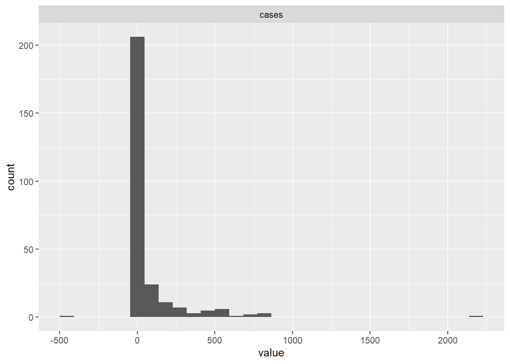

```r
ggplot(Japan_corona_1,aes(x=value))+geom_histogram()+
  facet_wrap(variable ~.,ncol=1)
```

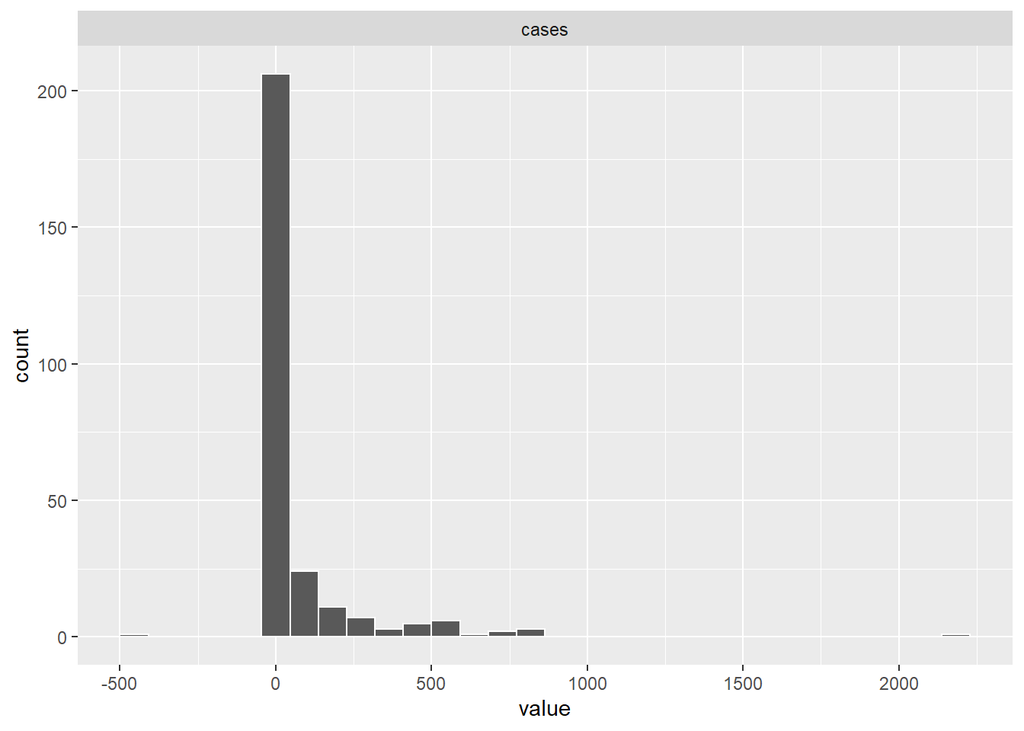

```r
ggplot(Japan_corona_1,aes(x=value))+geom_histogram(colour="white")+
  facet_wrap(variable ~.,ncol=1, scales="free")
```

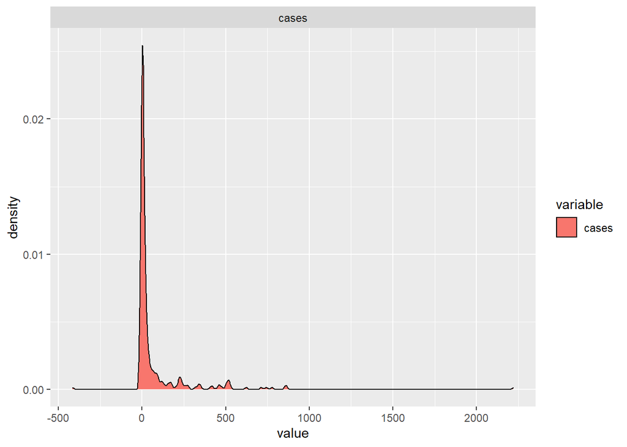

```r
ggplot(Japan_corona_1,aes(x=value, fill=variable))+geom_density()+
  facet_wrap(variable ~.,ncol=1, scales="free")
```

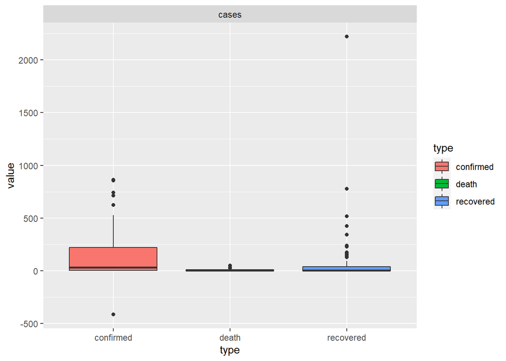

```r
ggplot(Japan_corona_1,aes(y=value, x=type, fill=type))+geom_boxplot()+
  facet_wrap(variable ~.,ncol=1, scales="free")
```

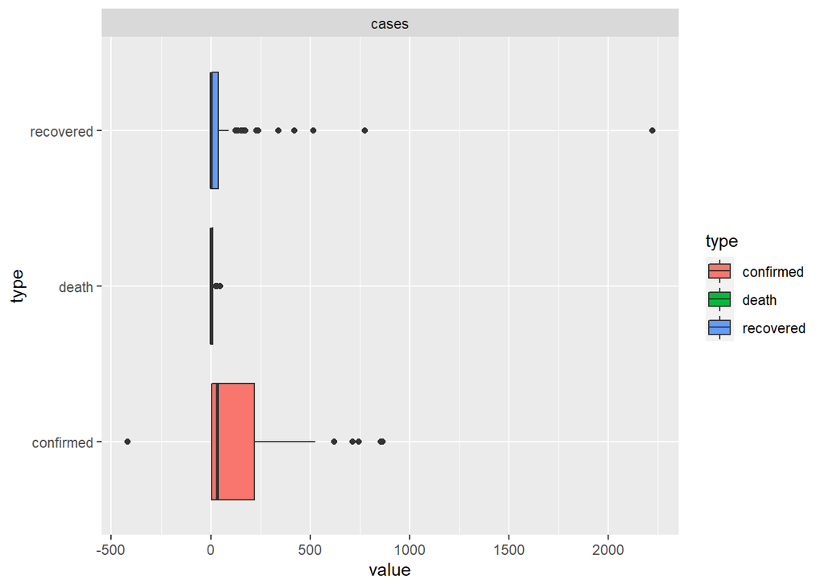

```r
ggplot(Japan_corona_1,aes(x=value, y=type, fill=type))+geom_boxplot()+
  facet_wrap(variable ~.,ncol=1, scales="free")
```

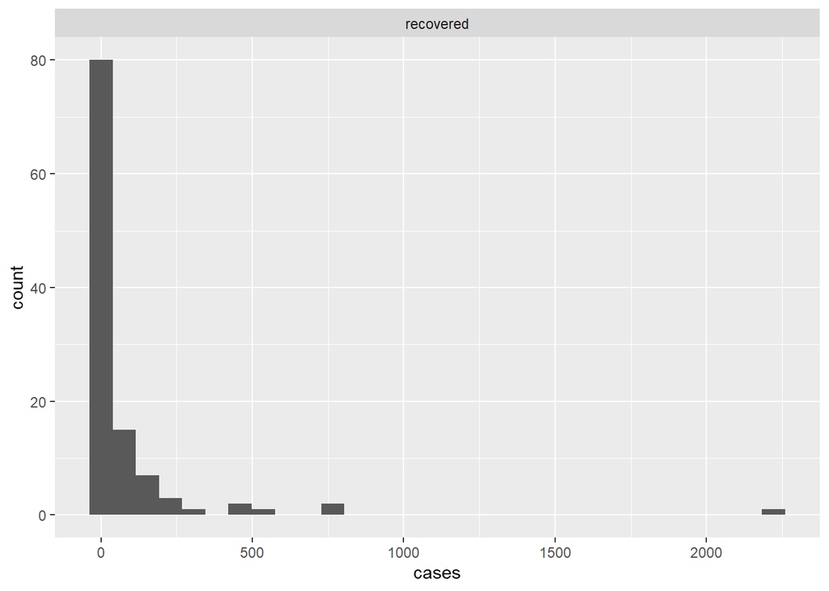

```r
ggplot(recover_japan_corona,aes(x=cases))+geom_histogram()+
  facet_wrap(type ~.,ncol=1, scales="free")
```

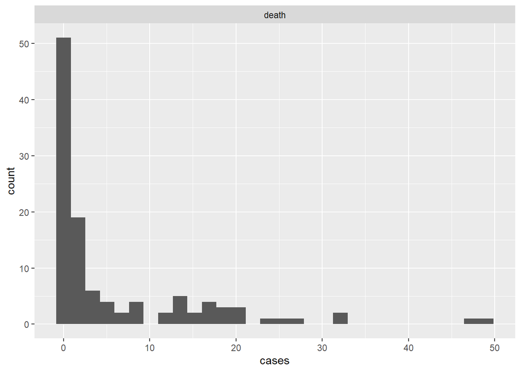

```r
ggplot(death_japan_corona,aes(x=cases))+geom_histogram()+
  facet_wrap(type ~.,ncol=1, scales="free")
```

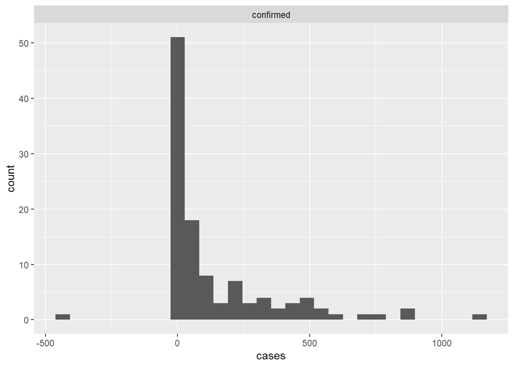

```r
ggplot(confirm_japan_corona,aes(x=cases))+geom_histogram()+
  facet_wrap(type ~.,ncol=1, scales="free")
```

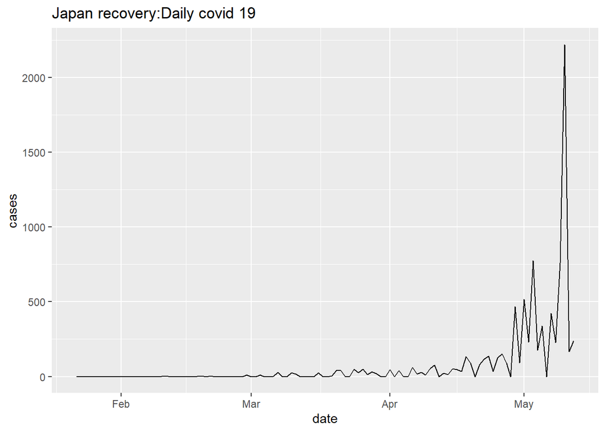

```r
ggplot(recover_japan_corona,aes(x=date, y=cases)) + geom_line()+ ggtitle("Japan recovery:Daily covid 19")
```

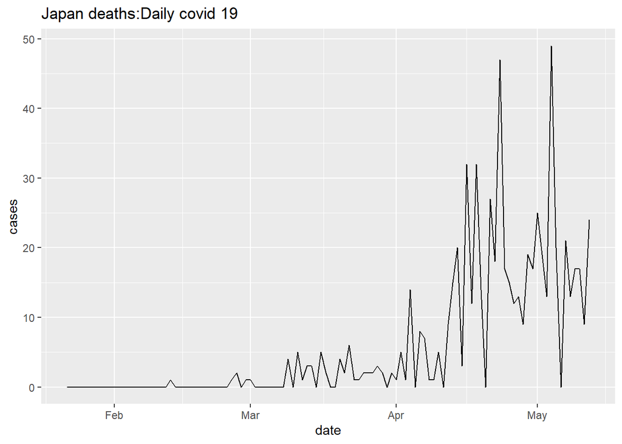

```r
ggplot(death_japan_corona,aes(x=date, y=cases)) + geom_line()+ ggtitle("Japan deaths:Daily covid 19")
```

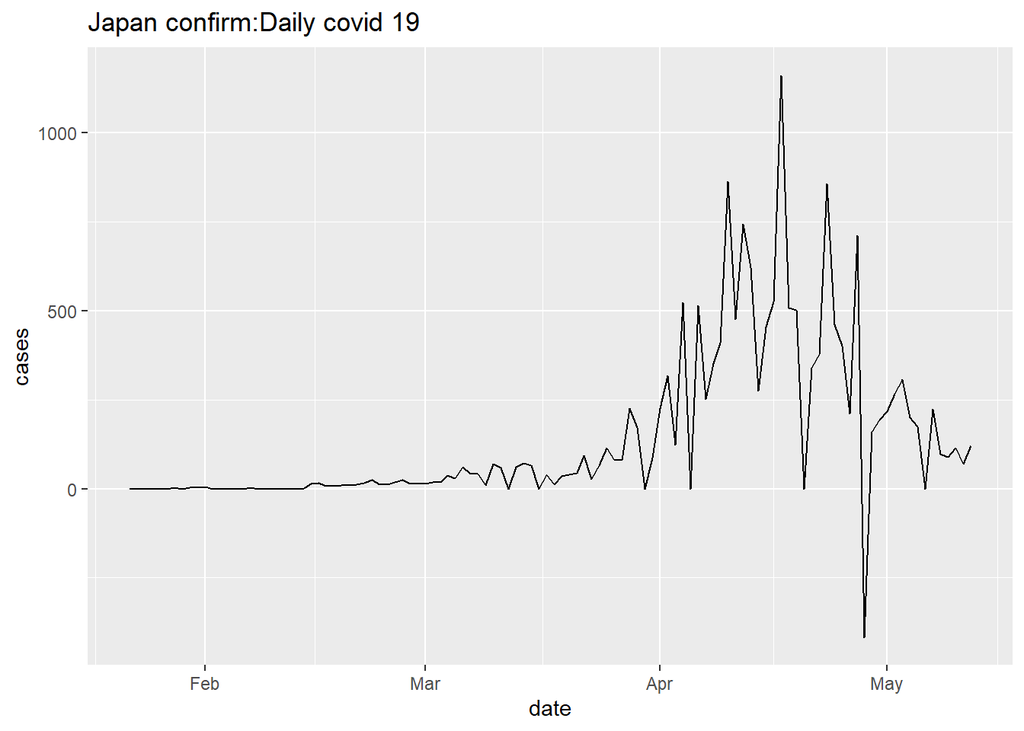

```r
ggplot(confirm_japan_corona,aes(x=date, y=cases)) + geom_line()+ ggtitle("Japan confirm:Daily covid 19")
```

#### comparison with Italy

```r
Italy_corona <- coronavirus %>% filter(country == "Italy")
head(Italy_corona)
```

```
##         date province country lat long      type cases
## 1 2020-01-22            Italy  43   12 confirmed     0
## 2 2020-01-23            Italy  43   12 confirmed     0
## 3 2020-01-24            Italy  43   12 confirmed     0
## 4 2020-01-25            Italy  43   12 confirmed     0
## 5 2020-01-26            Italy  43   12 confirmed     0
## 6 2020-01-27            Italy  43   12 confirmed     0
```

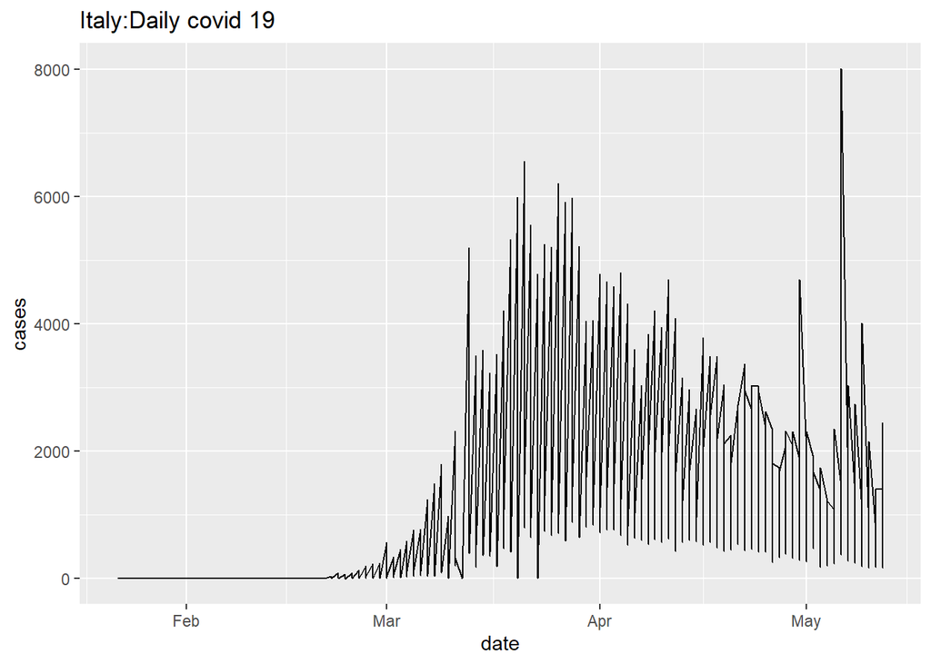

```r
ggplot(Italy_corona,aes(x=date, y=cases)) + geom_line()+ ggtitle("Italy:Daily covid 19")
```

```r
summary(Italy_corona)
```

```
##       date              province           country               lat
##  Min.   :2020-01-22   Length:336         Length:336         Min.   :43
##  1st Qu.:2020-02-18   Class :character   Class :character   1st Qu.:43
##  Median :2020-03-17   Mode  :character   Mode  :character   Median :43
##  Mean   :2020-03-17                                         Mean   :43
##  3rd Qu.:2020-04-14                                         3rd Qu.:43
##  Max.   :2020-05-12                                         Max.   :43
##       long        type               cases
##  Min.   :12   Length:336         Min.   :  -1
##  1st Qu.:12   Class :character   1st Qu.:   0
##  Median :12   Mode  :character   Median : 404
##  Mean   :12                      Mean   :1075
##  3rd Qu.:12                      3rd Qu.:1640
##  Max.   :12                      Max.   :8014
```

#### comparison with south korea

```r
Korea_South_corona <- coronavirus %>% filter(country == "Korea, South")
head(Korea_South_corona)
```

```
##         date province      country lat long      type cases
## 1 2020-01-22          Korea, South  36  128 confirmed     1
## 2 2020-01-23          Korea, South  36  128 confirmed     0
## 3 2020-01-24          Korea, South  36  128 confirmed     1
## 4 2020-01-25          Korea, South  36  128 confirmed     0
## 5 2020-01-26          Korea, South  36  128 confirmed     1
## 6 2020-01-27          Korea, South  36  128 confirmed     1
```

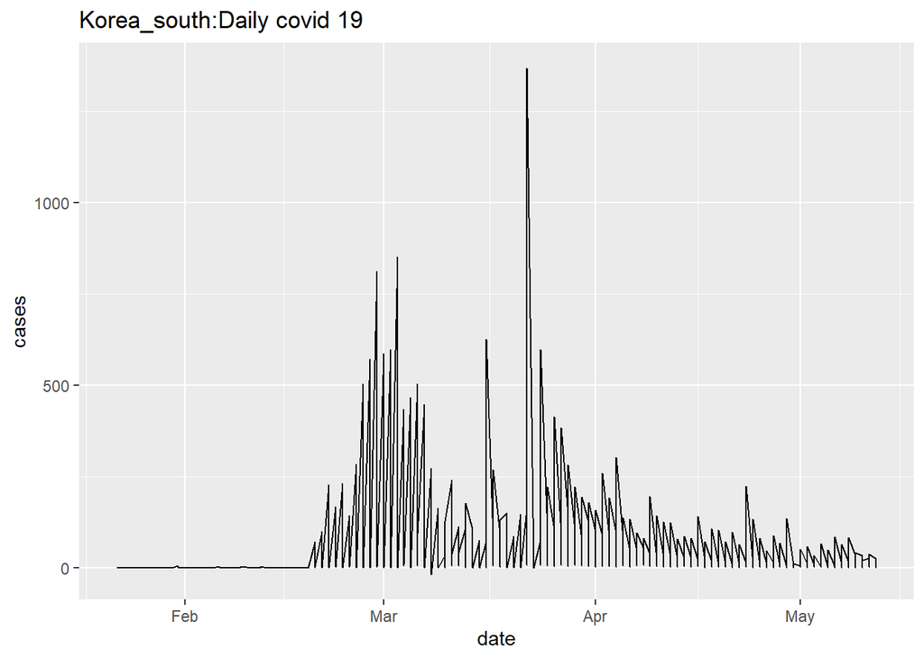

```r
ggplot(Korea_South_corona,aes(x=date, y=cases)) + geom_line()+ ggtitle("Korea_south:Daily covid 19")
```

```r
summary(Korea_South_corona)
```

```
##       date              province           country               lat
##  Min.   :2020-01-22   Length:336         Length:336         Min.   :36
##  1st Qu.:2020-02-18   Class :character   Class :character   1st Qu.:36
##  Median :2020-03-17   Mode  :character   Mode  :character   Median :36
##  Mean   :2020-03-17                                         Mean   :36
##  3rd Qu.:2020-04-14                                         3rd Qu.:36
##  Max.   :2020-05-12                                         Max.   :36
##       long         type               cases
##  Min.   :128   Length:336         Min.   : -17.00
##  1st Qu.:128   Class :character   1st Qu.:   0.00
##  Median :128   Mode  :character   Median :   4.00
##  Mean   :128                      Mean   :  62.25
##  3rd Qu.:128                      3rd Qu.:  73.25
##  Max.   :128                      Max.   :1369.00
```

3. Conclusions and Discussion